# Practical Machine Learning Project

JC Harrop

2017-07-16

## Summary

Motion senor data previously collected for studying weight lifting exercises was used in the exercise in practical machine learning (Velloso, E.; Bulling, A.; Gellersen, H.; Ugulino, W.; Fuks, H. 2013, Qualitative Activity Recognition of Weight Lifting Exercises) The data included measurements for both correctly performed dumbbell curls (class A) and four common errors (classes B, C, D and E). The current exercise was to train a model that could recognize what class of activity an instantaneous falls within. Following data cleaning and feature select a subset of observations were held back for CV/out-of-sample testing. A number of of algorithms were tested using the caret package with the gbm (Generalized Boosted Regression Models) package providing a sufficiently accurate solution in reasonable good training time.

## Data Cleaning

```
##    A    B    C    D    E
## 5580 3797 3422 3216 3607
```

## EDA and Feature Selection

A combination of scatter, box and density plots coloured by the “classe” parameter we examined for many of the motion sensor features. This appears to be where the science of data science meets the art of feature selection. A correlation plot was also done but the scatter plots were found to be the most useful in feature selection. Box and density plots also contributed to preliminary understanding of the training data. Two examples of scatter plots are presented below to illustrate this. Both are considered fairly correlated but in the upper one the classes are much more mixed than in the lower where there is significant clustering. In fact, plots like the lower one are quite encouraging that a predictive model of exercise class is possible. They also demonstrate how scatter plots can assist in feature selection beyond correlation plots.

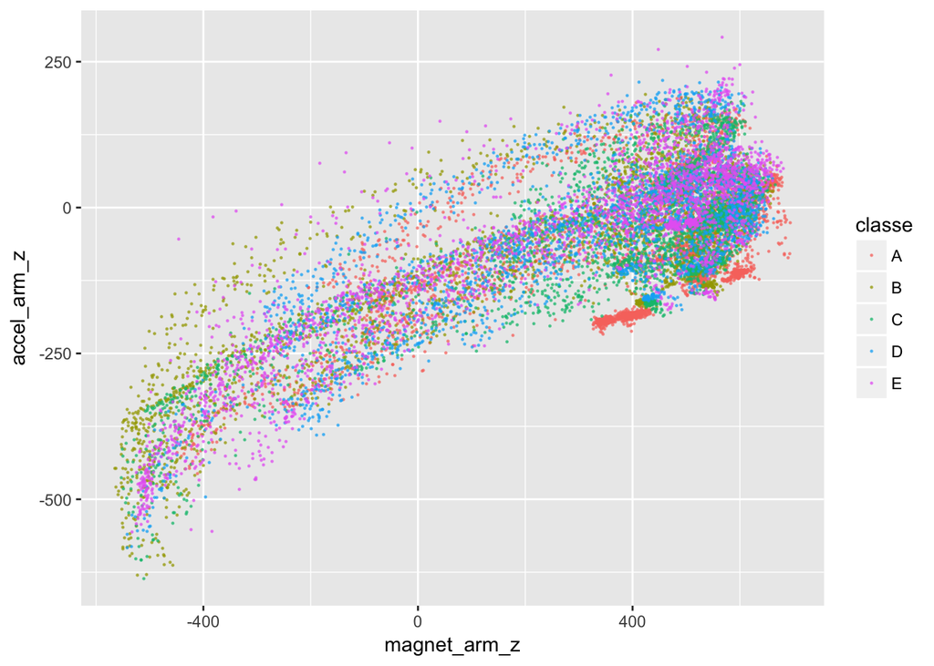

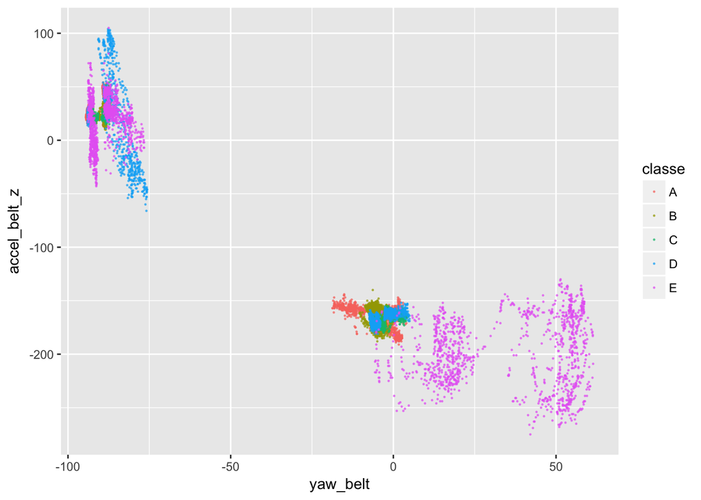

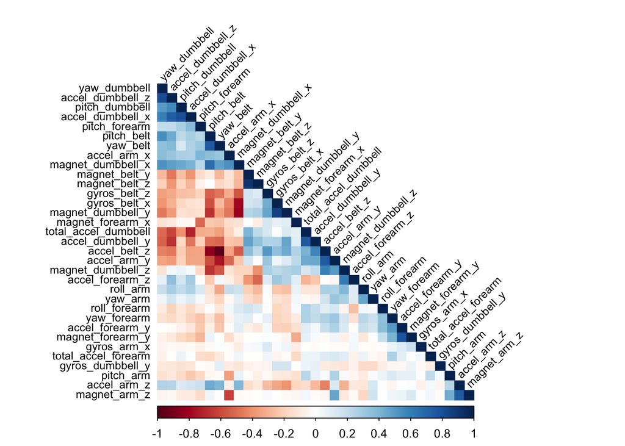

Now the data has be trimmed and filtered down to a working set we can separate out a testing set for cross validation. A 20% random subset is set aside.

## Modelling

A range of models available from within the caret package were examined including glm, gbm, rpart and rf. As configured, glm (general linear models) and rpart (r?? partitions) did not result in sufficiently accurate models to be useful in this exercise. A method of interest was rf (random forests) but even with parallel processing support implemented on an eight core machine, time and memory constraints made this method too expensive to use. The gbm (general boosting) method was chosen as the operating version since it took a reasonable amount of tie to complete and provided sufficient accuracy for the purposes of the project.

The time issues described above presented a serious challenge for cross validation (CV) choices. Although K-fold or random sub-sampling are different options, the fact that the training data is ordered by observation class means that the unless the order of training data is randomized K-fold will not be useful. However, it would appear that randomizing and subsequent K-folding is not significantly different than random sub-sampling to begin with. The time constraints of the assignment clearly rule out “leave one out” strategies. Wanting to be able to try a number of algorithms a primitive CV solution with lower time demand was selected. A 20% split of the training data was randomly sub-sampled using the caret package and set aside for out of sample testing. Given less tie constraint this area could be improved, but given the quite large training data it was thought to be a decent first pass.

## Models Result

First, we will look at the model’s predictive ability based on the data used for training.  
This result (97.9% accuracy) is likely not the best possible result, it looks like it could be more than enough to meet the prediction requirements of the assignment.

```
## Confusion Matrix and Statistics
##
##           Reference
## Prediction    A    B    C    D    E
##          A 3509   42    0    0    2
##          B   16 2325   32    2   13
##          C    6   39 2086   39   13
##          D    0    5   17 2113   23
##          E    1    5    3    7 2250
##
## Overall Statistics
##
##                Accuracy : 0.9789
##                  95% CI : (0.9762, 0.9813)
##     No Information Rate : 0.2815
##     P-Value [Acc > NIR] : < 2.2e-16
##
##                   Kappa : 0.9733
##  Mcnemar's Test P-Value : NA
##
## Statistics by Class:
##
##                      Class: A Class: B Class: C Class: D Class: E
## Sensitivity            0.9935   0.9623   0.9757   0.9778   0.9778
## Specificity            0.9951   0.9938   0.9907   0.9957   0.9984
## Pos Pred Value         0.9876   0.9736   0.9556   0.9791   0.9929
## Neg Pred Value         0.9974   0.9910   0.9950   0.9954   0.9950
## Prevalence             0.2815   0.1925   0.1704   0.1722   0.1834
## Detection Rate         0.2796   0.1853   0.1662   0.1684   0.1793
## Detection Prevalence   0.2832   0.1903   0.1740   0.1720   0.1806
## Balanced Accuracy      0.9943   0.9781   0.9832   0.9867   0.9881
```

But this is the in-sample error so we need to check that over-fitting has not excessively inflated the accuracy. Of greater interest is the out-of-sample error. To evaluate that we will use the test data that was withheld from training the model.

```
## Confusion Matrix and Statistics
##
##           Reference
## Prediction   A   B   C   D   E
##          A 868  18   0   0   0
##          B  10 567  14   0   5
##          C   3  18 515  13   4
##          D   1   0   5 523  10
##          E   0   1   0   4 556
##
## Overall Statistics
##
##                Accuracy : 0.9662
##                  95% CI : (0.9593, 0.9722)
##     No Information Rate : 0.2813
##     P-Value [Acc > NIR] : < 2.2e-16
##
##                   Kappa : 0.9573
##  Mcnemar's Test P-Value : NA
##
## Statistics by Class:
##
##                      Class: A Class: B Class: C Class: D Class: E
## Sensitivity            0.9841   0.9387   0.9644   0.9685   0.9670
## Specificity            0.9920   0.9885   0.9854   0.9938   0.9980
## Pos Pred Value         0.9797   0.9513   0.9313   0.9703   0.9911
## Neg Pred Value         0.9938   0.9854   0.9926   0.9935   0.9926
## Prevalence             0.2813   0.1927   0.1703   0.1722   0.1834
## Detection Rate         0.2769   0.1809   0.1643   0.1668   0.1774
## Detection Prevalence   0.2826   0.1901   0.1764   0.1719   0.1789
## Balanced Accuracy      0.9881   0.9636   0.9749   0.9812   0.9825
```

The accuracy of B type flawed exercise is also lower than the other types. Perhaps further review of the data, and additional information on the nature of type-B flaws would enable this misclassification to be reduced.

A characteristic of the prediction behaviour (also in the test behaviour) with no immediate explanation is why the majority of the misclassification is with the adjacent class. (Adjacent in the alphabetic sense.) Without knowing more about the type of flawed exercise that were being tested its not easy to see any mathematical or statistical reason why the misclassifications should not be more random. This is a slight red flag and might be worth investigation on a larger study.

## Discussion

Regardless, there are useful clues in the model as to what movement characteristics are associated with the flawed exercises. In conclusion, this assignment has many ways in which further work could be directed. Additional (more time expensive) tree based methods would be interesting to try, More comprehensive CV methods would also be appropriate in further work given more time to allow models to run.

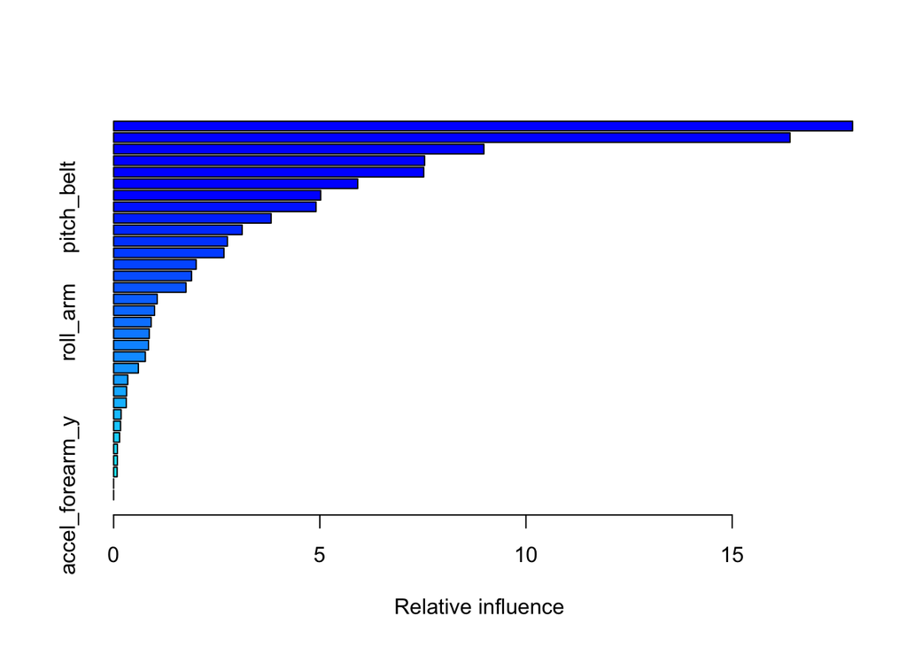

```
##                                       var     rel.inf
## yaw_belt                         yaw_belt 17.92074676
## pitch_forearm               pitch_forearm 16.40370564
## magnet_dumbbell_z       magnet_dumbbell_z  8.98036435
## magnet_dumbbell_y       magnet_dumbbell_y  7.54228557
## roll_forearm                 roll_forearm  7.52108353
## accel_dumbbell_y         accel_dumbbell_y  5.91907568
## magnet_belt_z               magnet_belt_z  5.02196830
## pitch_belt                     pitch_belt  4.90899727
## gyros_belt_z                 gyros_belt_z  3.81927983
## accel_dumbbell_x         accel_dumbbell_x  3.11652840
## gyros_dumbbell_y         gyros_dumbbell_y  2.75891143
## magnet_dumbbell_x       magnet_dumbbell_x  2.67527499
## accel_forearm_z           accel_forearm_z  2.00138947
## total_accel_dumbbell total_accel_dumbbell  1.88985205
## accel_dumbbell_z         accel_dumbbell_z  1.75550693
## magnet_forearm_y         magnet_forearm_y  1.05705881
## magnet_arm_z                 magnet_arm_z  0.99262227
## roll_arm                         roll_arm  0.90997987
## magnet_belt_y               magnet_belt_y  0.86484870
## magnet_forearm_x         magnet_forearm_x  0.84545941
## accel_belt_z                 accel_belt_z  0.76919616
## accel_arm_x                   accel_arm_x  0.60014779
## gyros_arm_x                   gyros_arm_x  0.34300676
## pitch_dumbbell             pitch_dumbbell  0.31449484
## yaw_dumbbell                 yaw_dumbbell  0.30710596
## accel_arm_y                   accel_arm_y  0.18133859
## total_accel_forearm   total_accel_forearm  0.16771327
## yaw_forearm                   yaw_forearm  0.14489300
## pitch_arm                       pitch_arm  0.09154503
## accel_arm_z                   accel_arm_z  0.09086532
## yaw_arm                           yaw_arm  0.08475401
## gyros_belt_x                 gyros_belt_x  0.00000000
## accel_forearm_y           accel_forearm_y  0.00000000
```

“So long, and thanks for all the fish!”"